# Risk Factor Analysis

## Outcome Variable

**Outcome Variable:** whz

## Predictor Variables

**Intervention Variable:** predfeed6

**Adjustment Set:**

- arm
- sex
- month
- brthmon
- W_mage
- meducyrs
- feducyrs
- hhwealth_quart
- hfoodsec
- W_mhtcm
- W_mwtkg
- W_mbmi
- vagbrth
- W_gagebrth
- W_birthwt
- W_birthlen
- W_nrooms
- W_nchldlt5
- W_parity
- impfloor
- impsan
- safeh20
- delta_W_mage
- delta_meducyrs
- delta_feducyrs
- delta_hhwealth_quart
- delta_hfoodsec
- delta_W_mhtcm
- delta_W_mwtkg
- delta_W_mbmi
- delta_vagbrth
- delta_W_gagebrth
- delta_W_birthwt
- delta_W_birthlen
- delta_W_nrooms
- delta_W_nchldlt5
- delta_W_parity
- delta_impfloor
- delta_impsan
- delta_safeh20

## Stratifying Variables

The analysis was stratified on these variable(s):

- agecat
- studyid
- country

## Data Summary

| agecat | studyid | country | predfeed6 | n_cell | n |
| --- | --- | --- | --- | --- | --- |
| Birth | ki0047075b-MAL-ED | BANGLADESH | 1 | 68 | 194 |
| Birth | ki0047075b-MAL-ED | BANGLADESH | 0 | 126 | 194 |
| Birth | ki0047075b-MAL-ED | BRAZIL | 1 | 5 | 57 |
| Birth | ki0047075b-MAL-ED | BRAZIL | 0 | 52 | 57 |
| Birth | ki0047075b-MAL-ED | INDIA | 1 | 4 | 37 |
| Birth | ki0047075b-MAL-ED | INDIA | 0 | 33 | 37 |
| Birth | ki0047075b-MAL-ED | NEPAL | 1 | 3 | 23 |
| Birth | ki0047075b-MAL-ED | NEPAL | 0 | 20 | 23 |
| Birth | ki0047075b-MAL-ED | PERU | 1 | 72 | 208 |
| Birth | ki0047075b-MAL-ED | PERU | 0 | 136 | 208 |
| Birth | ki0047075b-MAL-ED | SOUTH AFRICA | 1 | 1 | 90 |
| Birth | ki0047075b-MAL-ED | SOUTH AFRICA | 0 | 89 | 90 |
| Birth | ki0047075b-MAL-ED | TANZANIA, UNITED REPUBLIC OF | 1 | 0 | 105 |
| Birth | ki0047075b-MAL-ED | TANZANIA, UNITED REPUBLIC OF | 0 | 105 | 105 |
| Birth | ki1000109-EE | PAKISTAN | 1 | 24 | 28 |
| Birth | ki1000109-EE | PAKISTAN | 0 | 4 | 28 |
| Birth | ki1113344-GMS-Nepal | NEPAL | 1 | 390 | 522 |
| Birth | ki1113344-GMS-Nepal | NEPAL | 0 | 132 | 522 |
| Birth | kiGH5241-JiVitA-3 | BANGLADESH | 1 | 10161 | 13000 |
| Birth | kiGH5241-JiVitA-3 | BANGLADESH | 0 | 2839 | 13000 |
| Birth | kiGH5241-JiVitA-4 | BANGLADESH | 1 | 1802 | 2224 |
| Birth | kiGH5241-JiVitA-4 | BANGLADESH | 0 | 422 | 2224 |
| 6 months | ki0047075b-MAL-ED | BANGLADESH | 1 | 84 | 231 |
| 6 months | ki0047075b-MAL-ED | BANGLADESH | 0 | 147 | 231 |
| 6 months | ki0047075b-MAL-ED | BRAZIL | 1 | 30 | 209 |
| 6 months | ki0047075b-MAL-ED | BRAZIL | 0 | 179 | 209 |
| 6 months | ki0047075b-MAL-ED | INDIA | 1 | 11 | 218 |
| 6 months | ki0047075b-MAL-ED | INDIA | 0 | 207 | 218 |
| 6 months | ki0047075b-MAL-ED | NEPAL | 1 | 12 | 225 |
| 6 months | ki0047075b-MAL-ED | NEPAL | 0 | 213 | 225 |
| 6 months | ki0047075b-MAL-ED | PERU | 1 | 92 | 271 |
| 6 months | ki0047075b-MAL-ED | PERU | 0 | 179 | 271 |
| 6 months | ki0047075b-MAL-ED | SOUTH AFRICA | 1 | 3 | 233 |
| 6 months | ki0047075b-MAL-ED | SOUTH AFRICA | 0 | 230 | 233 |
| 6 months | ki0047075b-MAL-ED | TANZANIA, UNITED REPUBLIC OF | 1 | 1 | 232 |
| 6 months | ki0047075b-MAL-ED | TANZANIA, UNITED REPUBLIC OF | 0 | 231 | 232 |
| 6 months | ki1000109-EE | PAKISTAN | 1 | 43 | 48 |
| 6 months | ki1000109-EE | PAKISTAN | 0 | 5 | 48 |
| 6 months | ki1000304b-SAS-FoodSuppl | INDIA | 1 | 0 | 168 |
| 6 months | ki1000304b-SAS-FoodSuppl | INDIA | 0 | 168 | 168 |
| 6 months | ki1113344-GMS-Nepal | NEPAL | 1 | 406 | 547 |
| 6 months | ki1113344-GMS-Nepal | NEPAL | 0 | 141 | 547 |
| 6 months | ki1148112-LCNI-5 | MALAWI | 1 | 47 | 272 |
| 6 months | ki1148112-LCNI-5 | MALAWI | 0 | 225 | 272 |
| 6 months | kiGH5241-JiVitA-3 | BANGLADESH | 1 | 7605 | 9858 |
| 6 months | kiGH5241-JiVitA-3 | BANGLADESH | 0 | 2253 | 9858 |
| 6 months | kiGH5241-JiVitA-4 | BANGLADESH | 1 | 3327 | 4275 |
| 6 months | kiGH5241-JiVitA-4 | BANGLADESH | 0 | 948 | 4275 |
| 24 months | ki0047075b-MAL-ED | BANGLADESH | 1 | 76 | 205 |
| 24 months | ki0047075b-MAL-ED | BANGLADESH | 0 | 129 | 205 |
| 24 months | ki0047075b-MAL-ED | BRAZIL | 1 | 25 | 169 |
| 24 months | ki0047075b-MAL-ED | BRAZIL | 0 | 144 | 169 |
| 24 months | ki0047075b-MAL-ED | INDIA | 1 | 11 | 209 |
| 24 months | ki0047075b-MAL-ED | INDIA | 0 | 198 | 209 |
| 24 months | ki0047075b-MAL-ED | NEPAL | 1 | 12 | 219 |
| 24 months | ki0047075b-MAL-ED | NEPAL | 0 | 207 | 219 |
| 24 months | ki0047075b-MAL-ED | PERU | 1 | 68 | 201 |
| 24 months | ki0047075b-MAL-ED | PERU | 0 | 133 | 201 |
| 24 months | ki0047075b-MAL-ED | SOUTH AFRICA | 1 | 3 | 216 |
| 24 months | ki0047075b-MAL-ED | SOUTH AFRICA | 0 | 213 | 216 |
| 24 months | ki0047075b-MAL-ED | TANZANIA, UNITED REPUBLIC OF | 1 | 1 | 202 |
| 24 months | ki0047075b-MAL-ED | TANZANIA, UNITED REPUBLIC OF | 0 | 201 | 202 |
| 24 months | ki1000109-EE | PAKISTAN | 1 | 20 | 23 |
| 24 months | ki1000109-EE | PAKISTAN | 0 | 3 | 23 |
| 24 months | ki1113344-GMS-Nepal | NEPAL | 1 | 355 | 469 |
| 24 months | ki1113344-GMS-Nepal | NEPAL | 0 | 114 | 469 |
| 24 months | ki1148112-LCNI-5 | MALAWI | 1 | 34 | 184 |
| 24 months | ki1148112-LCNI-5 | MALAWI | 0 | 150 | 184 |
| 24 months | kiGH5241-JiVitA-3 | BANGLADESH | 1 | 3881 | 5028 |
| 24 months | kiGH5241-JiVitA-3 | BANGLADESH | 0 | 1147 | 5028 |
| 24 months | kiGH5241-JiVitA-4 | BANGLADESH | 1 | 3278 | 4184 |
| 24 months | kiGH5241-JiVitA-4 | BANGLADESH | 0 | 906 | 4184 |

The following strata were considered:

- agecat: 24 months, studyid: ki0047075b-MAL-ED, country: BANGLADESH
- agecat: 24 months, studyid: ki0047075b-MAL-ED, country: BRAZIL
- agecat: 24 months, studyid: ki0047075b-MAL-ED, country: INDIA
- agecat: 24 months, studyid: ki0047075b-MAL-ED, country: NEPAL
- agecat: 24 months, studyid: ki0047075b-MAL-ED, country: PERU
- agecat: 24 months, studyid: ki0047075b-MAL-ED, country: SOUTH AFRICA
- agecat: 24 months, studyid: ki0047075b-MAL-ED, country: TANZANIA, UNITED REPUBLIC OF
- agecat: 24 months, studyid: ki1000109-EE, country: PAKISTAN
- agecat: 24 months, studyid: ki1113344-GMS-Nepal, country: NEPAL
- agecat: 24 months, studyid: ki1148112-LCNI-5, country: MALAWI
- agecat: 24 months, studyid: kiGH5241-JiVitA-3, country: BANGLADESH
- agecat: 24 months, studyid: kiGH5241-JiVitA-4, country: BANGLADESH
- agecat: 6 months, studyid: ki0047075b-MAL-ED, country: BANGLADESH
- agecat: 6 months, studyid: ki0047075b-MAL-ED, country: BRAZIL
- agecat: 6 months, studyid: ki0047075b-MAL-ED, country: INDIA
- agecat: 6 months, studyid: ki0047075b-MAL-ED, country: NEPAL
- agecat: 6 months, studyid: ki0047075b-MAL-ED, country: PERU
- agecat: 6 months, studyid: ki0047075b-MAL-ED, country: SOUTH AFRICA
- agecat: 6 months, studyid: ki0047075b-MAL-ED, country: TANZANIA, UNITED REPUBLIC OF
- agecat: 6 months, studyid: ki1000109-EE, country: PAKISTAN
- agecat: 6 months, studyid: ki1000304b-SAS-FoodSuppl, country: INDIA
- agecat: 6 months, studyid: ki1113344-GMS-Nepal, country: NEPAL
- agecat: 6 months, studyid: ki1148112-LCNI-5, country: MALAWI
- agecat: 6 months, studyid: kiGH5241-JiVitA-3, country: BANGLADESH
- agecat: 6 months, studyid: kiGH5241-JiVitA-4, country: BANGLADESH
- agecat: Birth, studyid: ki0047075b-MAL-ED, country: BANGLADESH
- agecat: Birth, studyid: ki0047075b-MAL-ED, country: BRAZIL
- agecat: Birth, studyid: ki0047075b-MAL-ED, country: INDIA
- agecat: Birth, studyid: ki0047075b-MAL-ED, country: NEPAL
- agecat: Birth, studyid: ki0047075b-MAL-ED, country: PERU
- agecat: Birth, studyid: ki0047075b-MAL-ED, country: SOUTH AFRICA
- agecat: Birth, studyid: ki0047075b-MAL-ED, country: TANZANIA, UNITED REPUBLIC OF
- agecat: Birth, studyid: ki1000109-EE, country: PAKISTAN
- agecat: Birth, studyid: ki1113344-GMS-Nepal, country: NEPAL
- agecat: Birth, studyid: kiGH5241-JiVitA-3, country: BANGLADESH
- agecat: Birth, studyid: kiGH5241-JiVitA-4, country: BANGLADESH

### Dropped Strata

Some strata were dropped due to rare outcomes:

- agecat: Birth, studyid: ki0047075b-MAL-ED, country: INDIA
- agecat: Birth, studyid: ki0047075b-MAL-ED, country: NEPAL
- agecat: Birth, studyid: ki0047075b-MAL-ED, country: SOUTH AFRICA
- agecat: Birth, studyid: ki0047075b-MAL-ED, country: TANZANIA, UNITED REPUBLIC OF
- agecat: Birth, studyid: ki1000109-EE, country: PAKISTAN
- agecat: 6 months, studyid: ki0047075b-MAL-ED, country: SOUTH AFRICA
- agecat: 6 months, studyid: ki0047075b-MAL-ED, country: TANZANIA, UNITED REPUBLIC OF
- agecat: 6 months, studyid: ki1000304b-SAS-FoodSuppl, country: INDIA
- agecat: 24 months, studyid: ki0047075b-MAL-ED, country: SOUTH AFRICA
- agecat: 24 months, studyid: ki0047075b-MAL-ED, country: TANZANIA, UNITED REPUBLIC OF
- agecat: 24 months, studyid: ki1000109-EE, country: PAKISTAN

## Methods Detail

We’re interested in the causal parameters $E[Y_a]$ for all values of $a \in \mathcal{A}$. These parameters represent the mean outcome if, possibly contrary to fact, we intervened to set all units to have $A=a$. Under the randomization and positivity assumptions, these are identified by the statistical parameters $\psi_a=E_W[E_{Y|A,W}(Y|A=a,W)]$. In addition, we’re interested in the mean of $Y$, $E[Y]$ under no intervention (the observed mean). We will estimate these parameters by using SuperLearner to fit the relevant likelihood factors – $E_{Y|A,W}(Y|A=a,W)$ and $p(A=a|W)$, and then updating our likelihood fit using a joint TMLE.

For unadjusted analyses ($W=\{\}$), initial likelihoods were estimated using Lrnr_glm to estimate the simple $E(Y|A)$ and Lrnr_mean to estimate $p(A)$. For adjusted analyses, a small library containing Lrnr_glmnet, Lrnr_xgboost, and Lrnr_mean was used.

Having estimated these parameters, we will then use the delta method to estimate relative risks and attributable risks relative to a prespecified baseline level of $A$.

# Results Detail

## Results Plots

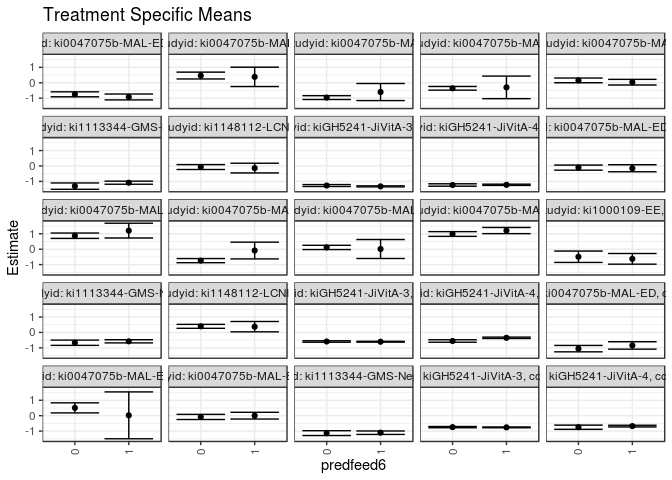

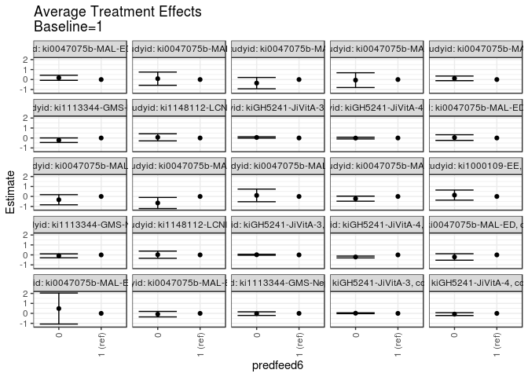

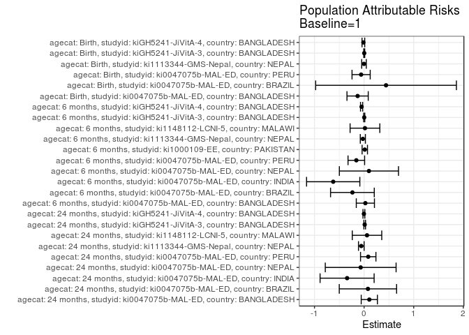

## Results Table

### Parameter: TSM

| agecat | studyid | country | intervention_level | baseline_level | estimate | ci_lower | ci_upper |
| --- | --- | --- | --- | --- | --- | --- | --- |
| Birth | ki0047075b-MAL-ED | BANGLADESH | 1 | NA | -0.8439987 | -1.0852265 | -0.6027710 |
| Birth | ki0047075b-MAL-ED | BANGLADESH | 0 | NA | -1.0508757 | -1.2579530 | -0.8437984 |
| Birth | ki0047075b-MAL-ED | BRAZIL | 1 | NA | 0.0220000 | -1.4978207 | 1.5418207 |
| Birth | ki0047075b-MAL-ED | BRAZIL | 0 | NA | 0.5069231 | 0.1803892 | 0.8334570 |
| Birth | ki0047075b-MAL-ED | PERU | 1 | NA | 0.0011671 | -0.2175427 | 0.2198769 |
| Birth | ki0047075b-MAL-ED | PERU | 0 | NA | -0.0812846 | -0.2473847 | 0.0848155 |
| Birth | ki1113344-GMS-Nepal | NEPAL | 1 | NA | -1.1043724 | -1.2166498 | -0.9920951 |
| Birth | ki1113344-GMS-Nepal | NEPAL | 0 | NA | -1.1315802 | -1.2892781 | -0.9738824 |
| Birth | kiGH5241-JiVitA-3 | BANGLADESH | 1 | NA | -0.7587763 | -0.7823833 | -0.7351694 |
| Birth | kiGH5241-JiVitA-3 | BANGLADESH | 0 | NA | -0.7439410 | -0.7841238 | -0.7037583 |
| Birth | kiGH5241-JiVitA-4 | BANGLADESH | 1 | NA | -0.6759365 | -0.7308168 | -0.6210561 |
| Birth | kiGH5241-JiVitA-4 | BANGLADESH | 0 | NA | -0.7497179 | -0.8858337 | -0.6136022 |
| 6 months | ki0047075b-MAL-ED | BANGLADESH | 1 | NA | -0.1476923 | -0.3765950 | 0.0812104 |
| 6 months | ki0047075b-MAL-ED | BANGLADESH | 0 | NA | -0.1052602 | -0.2700244 | 0.0595041 |
| 6 months | ki0047075b-MAL-ED | BRAZIL | 1 | NA | 1.2071853 | 0.7280773 | 1.6862933 |
| 6 months | ki0047075b-MAL-ED | BRAZIL | 0 | NA | 0.8768799 | 0.7023426 | 1.0514172 |
| 6 months | ki0047075b-MAL-ED | INDIA | 1 | NA | -0.0846648 | -0.6273576 | 0.4580279 |
| 6 months | ki0047075b-MAL-ED | INDIA | 0 | NA | -0.7411586 | -0.8744566 | -0.6078606 |
| 6 months | ki0047075b-MAL-ED | NEPAL | 1 | NA | 0.0122983 | -0.6033183 | 0.6279149 |
| 6 months | ki0047075b-MAL-ED | NEPAL | 0 | NA | 0.1158157 | -0.0234498 | 0.2550812 |
| 6 months | ki0047075b-MAL-ED | PERU | 1 | NA | 1.2111537 | 1.0108666 | 1.4114407 |
| 6 months | ki0047075b-MAL-ED | PERU | 0 | NA | 0.9884613 | 0.8348135 | 1.1421091 |
| 6 months | ki1000109-EE | PAKISTAN | 1 | NA | -0.6248062 | -0.9715960 | -0.2780164 |
| 6 months | ki1000109-EE | PAKISTAN | 0 | NA | -0.4893333 | -0.8590751 | -0.1195916 |
| 6 months | ki1113344-GMS-Nepal | NEPAL | 1 | NA | -0.5757489 | -0.6781045 | -0.4733933 |
| 6 months | ki1113344-GMS-Nepal | NEPAL | 0 | NA | -0.6683153 | -0.8384775 | -0.4981531 |
| 6 months | ki1148112-LCNI-5 | MALAWI | 1 | NA | 0.3750810 | 0.0392112 | 0.7109509 |
| 6 months | ki1148112-LCNI-5 | MALAWI | 0 | NA | 0.3960421 | 0.2688229 | 0.5232613 |
| 6 months | kiGH5241-JiVitA-3 | BANGLADESH | 1 | NA | -0.6022534 | -0.6294462 | -0.5750606 |
| 6 months | kiGH5241-JiVitA-3 | BANGLADESH | 0 | NA | -0.5870938 | -0.6323457 | -0.5418418 |
| 6 months | kiGH5241-JiVitA-4 | BANGLADESH | 1 | NA | -0.3464775 | -0.3913991 | -0.3015560 |
| 6 months | kiGH5241-JiVitA-4 | BANGLADESH | 0 | NA | -0.5556332 | -0.6359645 | -0.4753018 |
| 24 months | ki0047075b-MAL-ED | BANGLADESH | 1 | NA | -0.9232715 | -1.1132623 | -0.7332808 |
| 24 months | ki0047075b-MAL-ED | BANGLADESH | 0 | NA | -0.7504325 | -0.9123721 | -0.5884930 |
| 24 months | ki0047075b-MAL-ED | BRAZIL | 1 | NA | 0.3818513 | -0.2450403 | 1.0087429 |
| 24 months | ki0047075b-MAL-ED | BRAZIL | 0 | NA | 0.4667419 | 0.2449852 | 0.6884985 |
| 24 months | ki0047075b-MAL-ED | INDIA | 1 | NA | -0.6024681 | -1.1553264 | -0.0496098 |
| 24 months | ki0047075b-MAL-ED | INDIA | 0 | NA | -0.9625004 | -1.0873819 | -0.8376188 |
| 24 months | ki0047075b-MAL-ED | NEPAL | 1 | NA | -0.3004041 | -1.0329739 | 0.4321657 |
| 24 months | ki0047075b-MAL-ED | NEPAL | 0 | NA | -0.3621634 | -0.4824213 | -0.2419055 |
| 24 months | ki0047075b-MAL-ED | PERU | 1 | NA | 0.0370593 | -0.1464411 | 0.2205597 |
| 24 months | ki0047075b-MAL-ED | PERU | 0 | NA | 0.1532359 | 0.0013082 | 0.3051635 |
| 24 months | ki1113344-GMS-Nepal | NEPAL | 1 | NA | -1.0859439 | -1.1855779 | -0.9863099 |
| 24 months | ki1113344-GMS-Nepal | NEPAL | 0 | NA | -1.3079612 | -1.5135860 | -1.1023363 |
| 24 months | ki1148112-LCNI-5 | MALAWI | 1 | NA | -0.1358236 | -0.4515197 | 0.1798725 |
| 24 months | ki1148112-LCNI-5 | MALAWI | 0 | NA | -0.0694475 | -0.2290436 | 0.0901486 |
| 24 months | kiGH5241-JiVitA-3 | BANGLADESH | 1 | NA | -1.3235102 | -1.3586211 | -1.2883992 |
| 24 months | kiGH5241-JiVitA-3 | BANGLADESH | 0 | NA | -1.2696122 | -1.3326417 | -1.2065828 |
| 24 months | kiGH5241-JiVitA-4 | BANGLADESH | 1 | NA | -1.2227972 | -1.2629924 | -1.1826021 |
| 24 months | kiGH5241-JiVitA-4 | BANGLADESH | 0 | NA | -1.2339913 | -1.3116866 | -1.1562961 |

### Parameter: E(Y)

| agecat | studyid | country | intervention_level | baseline_level | estimate | ci_lower | ci_upper |
| --- | --- | --- | --- | --- | --- | --- | --- |
| Birth | ki0047075b-MAL-ED | BANGLADESH | NA | NA | -0.9748454 | -1.1280978 | -0.8215930 |
| Birth | ki0047075b-MAL-ED | BRAZIL | NA | NA | 0.4643860 | 0.1360519 | 0.7927200 |
| Birth | ki0047075b-MAL-ED | PERU | NA | NA | -0.0587981 | -0.1871869 | 0.0695908 |
| Birth | ki1113344-GMS-Nepal | NEPAL | NA | NA | -1.1064559 | -1.2034951 | -1.0094168 |
| Birth | kiGH5241-JiVitA-3 | BANGLADESH | NA | NA | -0.7557115 | -0.7768180 | -0.7346051 |
| Birth | kiGH5241-JiVitA-4 | BANGLADESH | NA | NA | -0.6904586 | -0.7435822 | -0.6373351 |
| 6 months | ki0047075b-MAL-ED | BANGLADESH | NA | NA | -0.1220707 | -0.2547831 | 0.0106417 |
| 6 months | ki0047075b-MAL-ED | BRAZIL | NA | NA | 0.9717225 | 0.8073791 | 1.1360658 |
| 6 months | ki0047075b-MAL-ED | INDIA | NA | NA | -0.7073471 | -0.8375598 | -0.5771344 |
| 6 months | ki0047075b-MAL-ED | NEPAL | NA | NA | 0.1097852 | -0.0259319 | 0.2455023 |
| 6 months | ki0047075b-MAL-ED | PERU | NA | NA | 1.0546617 | 0.9322137 | 1.1771098 |
| 6 months | ki1000109-EE | PAKISTAN | NA | NA | -0.6106944 | -0.9239621 | -0.2974268 |
| 6 months | ki1113344-GMS-Nepal | NEPAL | NA | NA | -0.6009171 | -0.6886356 | -0.5131986 |
| 6 months | ki1148112-LCNI-5 | MALAWI | NA | NA | 0.3925000 | 0.2735307 | 0.5114693 |
| 6 months | kiGH5241-JiVitA-3 | BANGLADESH | NA | NA | -0.5998808 | -0.6237974 | -0.5759642 |
| 6 months | kiGH5241-JiVitA-4 | BANGLADESH | NA | NA | -0.3968456 | -0.4358721 | -0.3578192 |
| 24 months | ki0047075b-MAL-ED | BANGLADESH | NA | NA | -0.8179024 | -0.9399789 | -0.6958260 |
| 24 months | ki0047075b-MAL-ED | BRAZIL | NA | NA | 0.4592308 | 0.2528453 | 0.6656163 |
| 24 months | ki0047075b-MAL-ED | INDIA | NA | NA | -0.9449522 | -1.0648865 | -0.8250178 |
| 24 months | ki0047075b-MAL-ED | NEPAL | NA | NA | -0.3690411 | -0.4853679 | -0.2527143 |
| 24 months | ki0047075b-MAL-ED | PERU | NA | NA | 0.1204478 | 0.0005049 | 0.2403906 |
| 24 months | ki1113344-GMS-Nepal | NEPAL | NA | NA | -1.1423525 | -1.2336321 | -1.0510729 |
| 24 months | ki1148112-LCNI-5 | MALAWI | NA | NA | -0.0770652 | -0.2204213 | 0.0662909 |
| 24 months | kiGH5241-JiVitA-3 | BANGLADESH | NA | NA | -1.3113405 | -1.3420927 | -1.2805883 |
| 24 months | kiGH5241-JiVitA-4 | BANGLADESH | NA | NA | -1.2265320 | -1.2620508 | -1.1910132 |

### Parameter: ATE

| agecat | studyid | country | intervention_level | baseline_level | estimate | ci_lower | ci_upper |
| --- | --- | --- | --- | --- | --- | --- | --- |
| Birth | ki0047075b-MAL-ED | BANGLADESH | 1 | 1 | 0.0000000 | 0.0000000 | 0.0000000 |
| Birth | ki0047075b-MAL-ED | BANGLADESH | 0 | 1 | -0.2068770 | -0.5335557 | 0.1198018 |
| Birth | ki0047075b-MAL-ED | BRAZIL | 1 | 1 | 0.0000000 | 0.0000000 | 0.0000000 |
| Birth | ki0047075b-MAL-ED | BRAZIL | 0 | 1 | 0.4849231 | -1.0695798 | 2.0394260 |
| Birth | ki0047075b-MAL-ED | PERU | 1 | 1 | 0.0000000 | 0.0000000 | 0.0000000 |
| Birth | ki0047075b-MAL-ED | PERU | 0 | 1 | -0.0824517 | -0.3579219 | 0.1930184 |
| Birth | ki1113344-GMS-Nepal | NEPAL | 1 | 1 | 0.0000000 | 0.0000000 | 0.0000000 |
| Birth | ki1113344-GMS-Nepal | NEPAL | 0 | 1 | -0.0272078 | -0.2094231 | 0.1550075 |
| Birth | kiGH5241-JiVitA-3 | BANGLADESH | 1 | 1 | 0.0000000 | 0.0000000 | 0.0000000 |
| Birth | kiGH5241-JiVitA-3 | BANGLADESH | 0 | 1 | 0.0148353 | -0.0299346 | 0.0596053 |
| Birth | kiGH5241-JiVitA-4 | BANGLADESH | 1 | 1 | 0.0000000 | 0.0000000 | 0.0000000 |
| Birth | kiGH5241-JiVitA-4 | BANGLADESH | 0 | 1 | -0.0737814 | -0.2167299 | 0.0691670 |
| 6 months | ki0047075b-MAL-ED | BANGLADESH | 1 | 1 | 0.0000000 | 0.0000000 | 0.0000000 |
| 6 months | ki0047075b-MAL-ED | BANGLADESH | 0 | 1 | 0.0424322 | -0.2399606 | 0.3248249 |
| 6 months | ki0047075b-MAL-ED | BRAZIL | 1 | 1 | 0.0000000 | 0.0000000 | 0.0000000 |
| 6 months | ki0047075b-MAL-ED | BRAZIL | 0 | 1 | -0.3303054 | -0.8388294 | 0.1782186 |
| 6 months | ki0047075b-MAL-ED | INDIA | 1 | 1 | 0.0000000 | 0.0000000 | 0.0000000 |
| 6 months | ki0047075b-MAL-ED | INDIA | 0 | 1 | -0.6564938 | -1.2156560 | -0.0973315 |
| 6 months | ki0047075b-MAL-ED | NEPAL | 1 | 1 | 0.0000000 | 0.0000000 | 0.0000000 |
| 6 months | ki0047075b-MAL-ED | NEPAL | 0 | 1 | 0.1035174 | -0.5280569 | 0.7350917 |
| 6 months | ki0047075b-MAL-ED | PERU | 1 | 1 | 0.0000000 | 0.0000000 | 0.0000000 |
| 6 months | ki0047075b-MAL-ED | PERU | 0 | 1 | -0.2226924 | -0.4754483 | 0.0300636 |
| 6 months | ki1000109-EE | PAKISTAN | 1 | 1 | 0.0000000 | 0.0000000 | 0.0000000 |
| 6 months | ki1000109-EE | PAKISTAN | 0 | 1 | 0.1354729 | -0.3714513 | 0.6423970 |
| 6 months | ki1113344-GMS-Nepal | NEPAL | 1 | 1 | 0.0000000 | 0.0000000 | 0.0000000 |
| 6 months | ki1113344-GMS-Nepal | NEPAL | 0 | 1 | -0.0925664 | -0.2910783 | 0.1059455 |
| 6 months | ki1148112-LCNI-5 | MALAWI | 1 | 1 | 0.0000000 | 0.0000000 | 0.0000000 |
| 6 months | ki1148112-LCNI-5 | MALAWI | 0 | 1 | 0.0209610 | -0.3386133 | 0.3805354 |
| 6 months | kiGH5241-JiVitA-3 | BANGLADESH | 1 | 1 | 0.0000000 | 0.0000000 | 0.0000000 |
| 6 months | kiGH5241-JiVitA-3 | BANGLADESH | 0 | 1 | 0.0151596 | -0.0364584 | 0.0667775 |
| 6 months | kiGH5241-JiVitA-4 | BANGLADESH | 1 | 1 | 0.0000000 | 0.0000000 | 0.0000000 |
| 6 months | kiGH5241-JiVitA-4 | BANGLADESH | 0 | 1 | -0.2091556 | -0.3004949 | -0.1178163 |
| 24 months | ki0047075b-MAL-ED | BANGLADESH | 1 | 1 | 0.0000000 | 0.0000000 | 0.0000000 |
| 24 months | ki0047075b-MAL-ED | BANGLADESH | 0 | 1 | 0.1728390 | -0.0804808 | 0.4261588 |
| 24 months | ki0047075b-MAL-ED | BRAZIL | 1 | 1 | 0.0000000 | 0.0000000 | 0.0000000 |
| 24 months | ki0047075b-MAL-ED | BRAZIL | 0 | 1 | 0.0848905 | -0.5792868 | 0.7490678 |
| 24 months | ki0047075b-MAL-ED | INDIA | 1 | 1 | 0.0000000 | 0.0000000 | 0.0000000 |
| 24 months | ki0047075b-MAL-ED | INDIA | 0 | 1 | -0.3600323 | -0.9274232 | 0.2073587 |
| 24 months | ki0047075b-MAL-ED | NEPAL | 1 | 1 | 0.0000000 | 0.0000000 | 0.0000000 |
| 24 months | ki0047075b-MAL-ED | NEPAL | 0 | 1 | -0.0617593 | -0.8019139 | 0.6783953 |
| 24 months | ki0047075b-MAL-ED | PERU | 1 | 1 | 0.0000000 | 0.0000000 | 0.0000000 |
| 24 months | ki0047075b-MAL-ED | PERU | 0 | 1 | 0.1161766 | -0.1165091 | 0.3488623 |
| 24 months | ki1113344-GMS-Nepal | NEPAL | 1 | 1 | 0.0000000 | 0.0000000 | 0.0000000 |
| 24 months | ki1113344-GMS-Nepal | NEPAL | 0 | 1 | -0.2220173 | -0.4500440 | 0.0060095 |
| 24 months | ki1148112-LCNI-5 | MALAWI | 1 | 1 | 0.0000000 | 0.0000000 | 0.0000000 |
| 24 months | ki1148112-LCNI-5 | MALAWI | 0 | 1 | 0.0663760 | -0.2887702 | 0.4215223 |
| 24 months | kiGH5241-JiVitA-3 | BANGLADESH | 1 | 1 | 0.0000000 | 0.0000000 | 0.0000000 |
| 24 months | kiGH5241-JiVitA-3 | BANGLADESH | 0 | 1 | 0.0538979 | -0.0180184 | 0.1258142 |
| 24 months | kiGH5241-JiVitA-4 | BANGLADESH | 1 | 1 | 0.0000000 | 0.0000000 | 0.0000000 |
| 24 months | kiGH5241-JiVitA-4 | BANGLADESH | 0 | 1 | -0.0111941 | -0.0965805 | 0.0741923 |

### Parameter: PAR

| agecat | studyid | country | intervention_level | baseline_level | estimate | ci_lower | ci_upper |
| --- | --- | --- | --- | --- | --- | --- | --- |
| Birth | ki0047075b-MAL-ED | BANGLADESH | 1 | NA | -0.1308466 | -0.3451953 | 0.0835021 |
| Birth | ki0047075b-MAL-ED | BRAZIL | 1 | NA | 0.4423860 | -0.9762121 | 1.8609840 |
| Birth | ki0047075b-MAL-ED | PERU | 1 | NA | -0.0599652 | -0.2432865 | 0.1233561 |
| Birth | ki1113344-GMS-Nepal | NEPAL | 1 | NA | -0.0020835 | -0.0479675 | 0.0438005 |
| Birth | kiGH5241-JiVitA-3 | BANGLADESH | 1 | NA | 0.0030648 | -0.0067040 | 0.0128336 |
| Birth | kiGH5241-JiVitA-4 | BANGLADESH | 1 | NA | -0.0145221 | -0.0419066 | 0.0128623 |
| 6 months | ki0047075b-MAL-ED | BANGLADESH | 1 | NA | 0.0256216 | -0.1573024 | 0.2085456 |
| 6 months | ki0047075b-MAL-ED | BRAZIL | 1 | NA | -0.2354628 | -0.6761566 | 0.2052309 |
| 6 months | ki0047075b-MAL-ED | INDIA | 1 | NA | -0.6226823 | -1.1595319 | -0.0858327 |
| 6 months | ki0047075b-MAL-ED | NEPAL | 1 | NA | 0.0974869 | -0.4985532 | 0.6935270 |
| 6 months | ki0047075b-MAL-ED | PERU | 1 | NA | -0.1564919 | -0.3238776 | 0.0108938 |
| 6 months | ki1000109-EE | PAKISTAN | 1 | NA | 0.0141118 | -0.0400020 | 0.0682256 |
| 6 months | ki1113344-GMS-Nepal | NEPAL | 1 | NA | -0.0251682 | -0.0764495 | 0.0261131 |
| 6 months | ki1148112-LCNI-5 | MALAWI | 1 | NA | 0.0174190 | -0.2822140 | 0.3170519 |
| 6 months | kiGH5241-JiVitA-3 | BANGLADESH | 1 | NA | 0.0023726 | -0.0094001 | 0.0141452 |
| 6 months | kiGH5241-JiVitA-4 | BANGLADESH | 1 | NA | -0.0503681 | -0.0719828 | -0.0287533 |
| 24 months | ki0047075b-MAL-ED | BANGLADESH | 1 | NA | 0.1053691 | -0.0578743 | 0.2686125 |
| 24 months | ki0047075b-MAL-ED | BRAZIL | 1 | NA | 0.0773794 | -0.5004274 | 0.6551863 |
| 24 months | ki0047075b-MAL-ED | INDIA | 1 | NA | -0.3424840 | -0.8872206 | 0.2022525 |
| 24 months | ki0047075b-MAL-ED | NEPAL | 1 | NA | -0.0686370 | -0.7823392 | 0.6450652 |
| 24 months | ki0047075b-MAL-ED | PERU | 1 | NA | 0.0833884 | -0.0716769 | 0.2384538 |
| 24 months | ki1113344-GMS-Nepal | NEPAL | 1 | NA | -0.0564086 | -0.1129000 | 0.0000828 |
| 24 months | ki1148112-LCNI-5 | MALAWI | 1 | NA | 0.0587583 | -0.2384397 | 0.3559564 |
| 24 months | kiGH5241-JiVitA-3 | BANGLADESH | 1 | NA | 0.0121697 | -0.0041943 | 0.0285336 |
| 24 months | kiGH5241-JiVitA-4 | BANGLADESH | 1 | NA | -0.0037348 | -0.0225205 | 0.0150509 |